# Identifying and Utilizing Research Topics in Conference Abstracts

May 19, 2018

## Task at hand

One of the authors is serving as a Program Chair of the Survey Methods Research Section of the ASA.

Computers must process the data, while humans should spend time thinking… wouldn’t it be great if computers could analyze the text of the abstracts and create the conference program??

## Scope

- Scrape 10 years of JSM abstracts (2008 – 2017)
- Pre-process text data for analysis
- Descriptive text modeling (NMF, LDA)
- Expert-informed classification of topics

## Web scraping

- Interactive search pages required using Selenium, a Python library that allows you to control a web browser programmatically
  - slowest of the web scraping libraries
- Different web page structures across years
- Location/referencing (within html) of each variable was slightly different from year to year

https://ww2.amstat.org/meetings/jsm/2017/onlineprogram/index.cfm

## Data preprocessing

1. Data Cleaning
   - remove all observations with no content in abstract text
   - include only observations sponsored by SRMS
2. Tokenize text into individual words (aka tokens)
3. Lemmatize text
   - `analyzing`, `analyze`, `analyzes` -> `analyz*`
4. Remove stopwords
   - `the`, `of`, `are`, `is`, `thereby`, `however`, etc
   - additional stopwords for this project: `data`, `roundtable`

## Vectorize text

Convert text data into its numeric representation

1. Frequency Count -> raw counts of words
   - Used in Latent Dirichlet Allocation
2. Term Frequency -> Inverse Document Frequency (TF-IDF)
   - Used in Non-negative Matrix Factorization

## Histograms

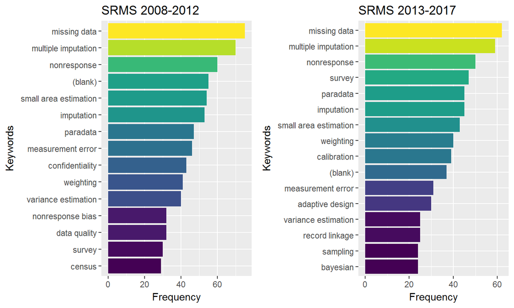

## Non-negative Matrix Factorization (NMF)

- Unsupervised learning algorithm intended to extract common features
- Represented as a weighted sum of some components
- Product of document-term matrix and topic-term matrix to approximate document-topic matrix
- Another name for spectral embedding (??)

## Latent Dirichlet Allocation (LDA)

- Groups of words that frequently appear together indicate a *topic*
- Each document contains a mixture of topics
- Probabilistic model using P(word|topic) to obtain P(topic|document)
  - underlying EM-algorithm: probabilities are calculated iteratively until convergence

## Limitations

- Unsupervised machine learning results should be taken with a grain of salt
- “Topics” as uncovered by machine learning models may not be the same as how humans understand a coherent topic
  - For machine learning models, “topics” are comprised of components which may or may not have semantic meaning
  - Different author writing styles may be picked up as different topics
- Pre-processing data and model parameters may dramatically change the separation of topics

## Research classifications

- American Mathematical Society: Mathematics Subject classification (http://www.ams.org/mathscinet/msc/msc2010.html).
  - `[0-9]{2}[A-Z]{0-9]{2}`
  - `62D05` Sampling theory, sample surveys.
  - `62P25` Applications to social sciences
- Journal of Economic Literature: JEL Classification (http://ideas.repec.org/j/)
  - `[A-Z][0-9]{2}`
  - Used in virtually all papers, as well as job announcements
  - `C83`: Survey Methods; Sampling Methods

## Research in survey methods

`[A-Z]{2}[0-9]{1,2}\.[0-9]`

Top level:

- `F`: **Fields/findings**: substantive areas.
- `M`: **Methodology**: social science methodology
- `O`: **Operations**: data collection, field issues
- `P`: **Professional matters**
- `S`: **Statistics**: statistical aspects of survey research

## Second level

- `SA`: Analysis of complex survey data
- `SD`: Disclosure and confidentiality protection
- `SI`: Statistical inference
- `SL`: Longitudinal data
- `SM`: Missing data, imputation and editing
- `SP`: Survey paradata
- `SS`: Sampling
- `SW`: Weighting

## Detailed examples

- `SM4.5`: multiple imputation
- `SI3.1`: calibration estimation
- `SW0.3`: calibrated weights
- `SS4.2`: coverage error
- `SI1.5`: bootstrap replicate variance estimation
- `SP2.5`: adaptive survey design
- `SA10.0`: social network analysis

## Abstract similarity

- the more symbols the two codes share, the closer the topics are
- the more codes the two abstracts share, the closer they are
- similarity =
  - 1, if two codes are identical
  - a<sub>1</sub>, if two codes share the stem up to the dot
  - a<sub>2</sub>, if two codes share the two letters
  - a<sub>3</sub>, if two codes share the first letter only
  - 0, if two codes have different first letter

## Tentative workflow

- Assign codes to keywords (~500)
- Assign codes to existing abstracts
- Tune parameters of the similarity metric based on historic clustering of abstracts to sessions
- Apply the parameters to the current (2018) abstracts to gauge their similarity
- Cluster 6-7 abstracts per contributed session

## Clustering new abstracts

- Convert keywords to codes
- Extract keywords from title, convert to codes
  - Abstract text can be used, too
- Compute similarity measures using the optimal parameters
- Run a clustering algorithm
  - Convert similarity to dissimilarity/distance

## Complete linkage

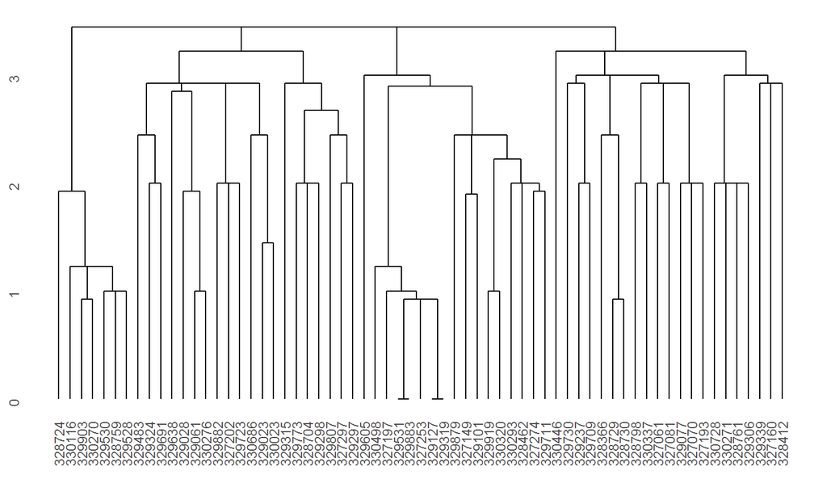

## Are we there yet?

Results not quite great… yet

- Classification is not complete enough
- Many keywords rename uncoded and hence not used
- Custom clustering algorithms may be needed

Real life:

- Conference programming means abstracts will come from other sections

## Thanks

Stas_Kolenikov@abtassoc.com

Twitter: @StatStas

This presentation: https://github.com/skolenik/SDSS2018.git

The views are of the authors only, and do not represent those of Abt Associates.